# Exercice 5

Gabriel Aubin-Moreau

2022-09-21

# Tâche 1: Réflection

Le thème est un élément extrêmement important qui ne doit pas être négligé. Et celui-ci peut faire toute la différence dans la façon dont l’auditoire va comprendre notre graphique. Un des éléments du thèmes qui peut faire une énorme différence est le « grid line ». Cet élément peut s’avérer très utile s’il est utilisé de la bonne façon. Par exemple, si le graphique ne requière pas de lecture de données précises ou qu’il n’y a pas d’ambiguïté dans la lecture des données, il est préférable de retirer la « grid line » complètement ou de la rendre très pâle pour éviter quel ne prenne inutilement l’attention du lecteur. On peut aussi, au besoin, mettre une ligne de grille sur seulement un des deux axes. Le thème est aussi utile pour configurer la disposition générale des éléments de manières à attirer l’attention du lecteur au bon endroit et pour faciliter la lecture du graphique.

# Tâche 2: graphique moche

Duncan Greere a rassemblé une base de données de 48 chiens soviétiques qui ont volé comme sujets de test dans le programme spatial de l’URSS dans les années 1950 et 1960. [Les données originales peuvent être trouvées ici](https://airtable.com/universe/expG3z2CFykG1dZsp/sovet-space-dogs).

## Charger et nettoyer les données

Nous chargeons et nettoyons d’abord les données.

```r
# Vous n'aurez besoin que de la bibliothèque tidyverse pour cet exercice
library(tidyverse)

space_dogs_raw <- read_csv("data/Dogs-Database.csv")

space_dogs <- space_dogs_raw %>%
# La colonne Fate semble indiquer soit "Survived" ou "Dead <DATE>", donc nous faisons
  # une nouvelle version binaire de la colonne Fate qui est "Survived" si le chien
  # a survécu et "Died" sinon
  mutate(Fate_binary = ifelse(Fate == "Survived", "Survived", "Died")) %>%
# Les données répertorient les dates de chaque vol, séparées par une virgule. Pour les convertir
  # en nombre, on utilise une petite astuce : compter le nombre de virgules dans la
  # cellule et ajoutez 1 (s'il y avait 2 vols, il y aurait 1 virgule, etc.)
  mutate(Flights_num = str_count(Flights, ",") + 1)
```

```r
# On résume les données par fate et gender
space_dogs_summarized <- space_dogs %>%
  group_by(Fate_binary, Gender) %>%
  summarize(total_dogs = n(),
            total_flights = sum(Flights_num))

space_dogs_summarized
```

```
## # A tibble: 4 x 4
## # Groups:   Fate_binary [2]
##   Fate_binary Gender total_dogs total_flights
##   <chr>       <chr>       <int>         <dbl>
## 1 Died        Female         14            18
## 2 Died        Male            6            10
## 3 Survived    Female         19            43
## 4 Survived    Male            9            10
```

## Graphique laid

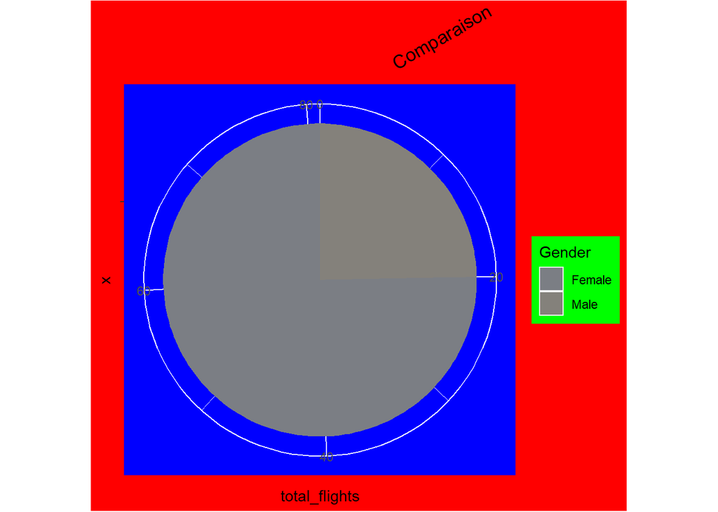

```r
ugly_plot <- ggplot(data = space_dogs_summarized,
                    mapping = aes(x = "",
                                  y = total_flights,
                                  fill = Gender)) +
  geom_bar(width = 1, stat = "identity") +
  scale_fill_manual(values = c("#7B7E84", "#84817B")) +
  coord_polar("y", start=0) +
  labs(title = "Comparaison") +
  theme(plot.background = element_rect(fill = "red"),
        panel.background = element_rect(fill = "blue"),
        legend.background = element_rect(fill = "green"),
        plot.title = element_text(hjust = 0.9, angle = 30))

ugly_plot
```

```r
# Enregistrez le tracé au format PNG avec ggsave()
ggsave("Graphique_moche.png")
```